# Auditory Mountain

July 10 2015

## Individual analyses

## Frequency threshold task

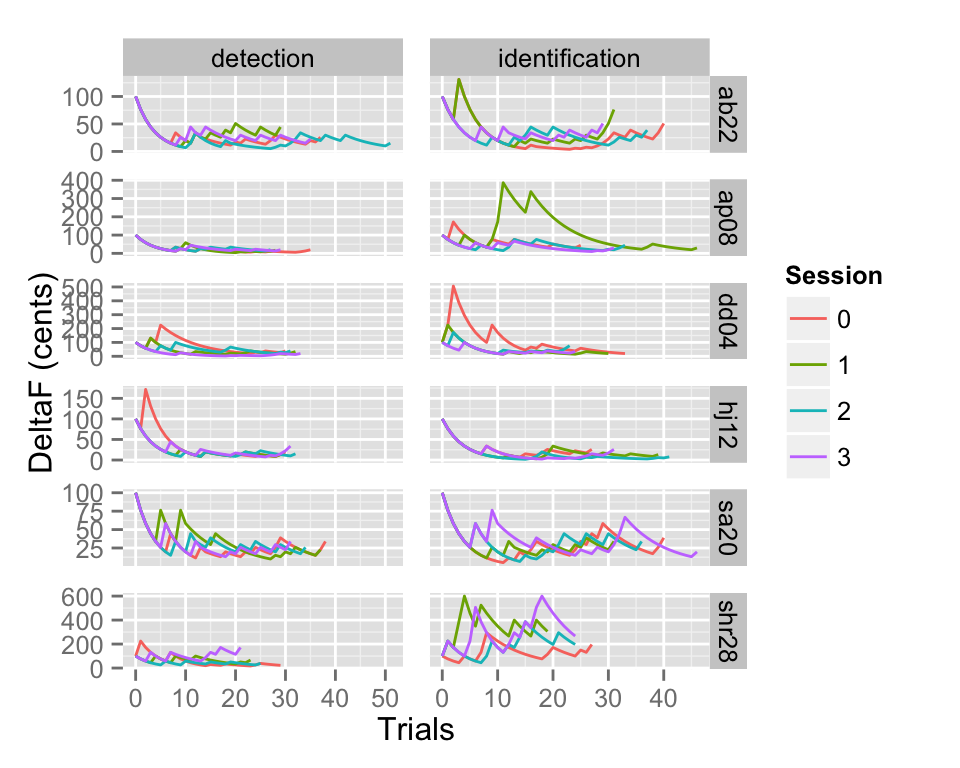

## Thresholds of each participant among sessions

The thresholds are calculated from the DeltaF values corresponding to the last 10 reversals. The procedure was repeated two times before training (sessions 1 and 2) and two times after (sessions 3 and 4). The figure bellow shows these thresholds across sessions for the detection and identification conditions:

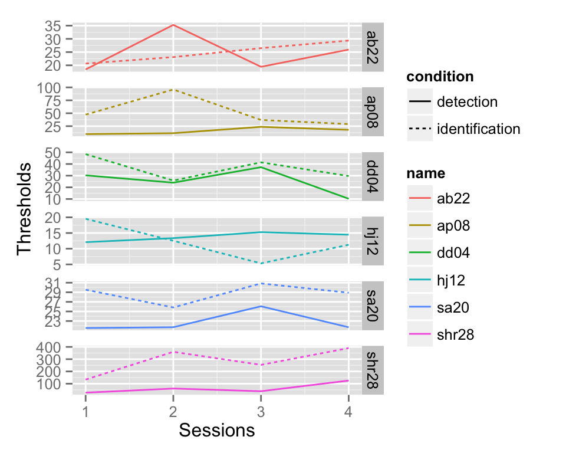

## Detection threshold in function of identification threshold

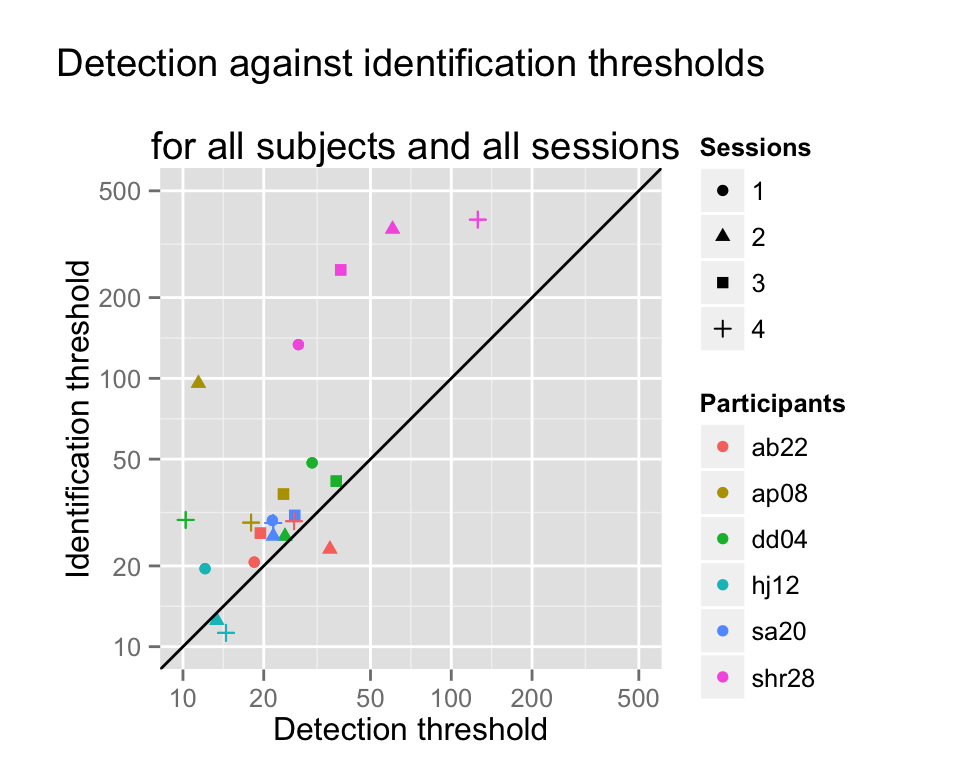

## Detection threshold in function of identification threshold pre vs. post tests

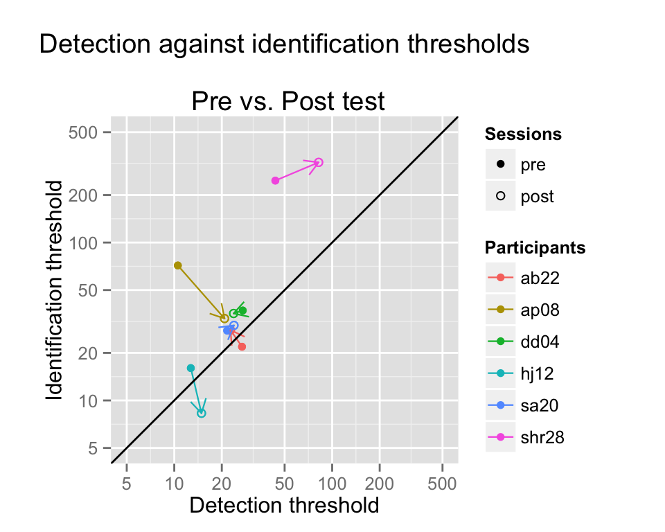

## Detection threshold in function of identification threshold first vs. second tests

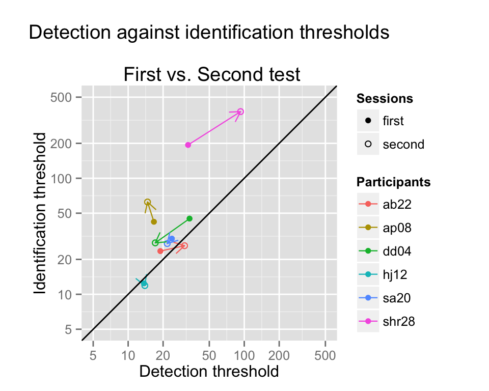

## Auditory mountain task

### Mean results (in percent error):

**Y-axis**: 2.5838194%

Here are the plots of scores, accuracy and duration in function of trials. The accuracy is the difference between the choosen tone and the highest tone. The Duration is the duration in seconds of each trial. The Score is a mixed value calculated from accuracy and duration according to this equation:

\[ (\frac{1}{(\frac{duration}{100}+1)^2} + 1) \times (\frac{600 \times accuracy}{100})^2 \]

With this equation the time score is a multiplier between 1 for a very long trial and 2 for a very short one (few seconds). Thus, the accuracy score can be doubled with speed. The accuracy score is 600 maximum (the idea was to make a score in order to have the pleasure to cross 1000 points when the performance is great). For accuracy and time, the power function is used to provide the maximum of points near the perfect score and have a lot of difference when it is harder.

## Participant's scores

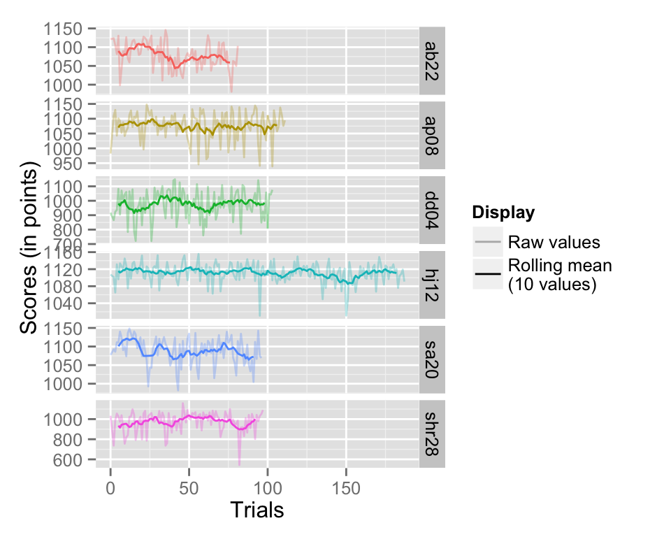

## Accuracy of trials

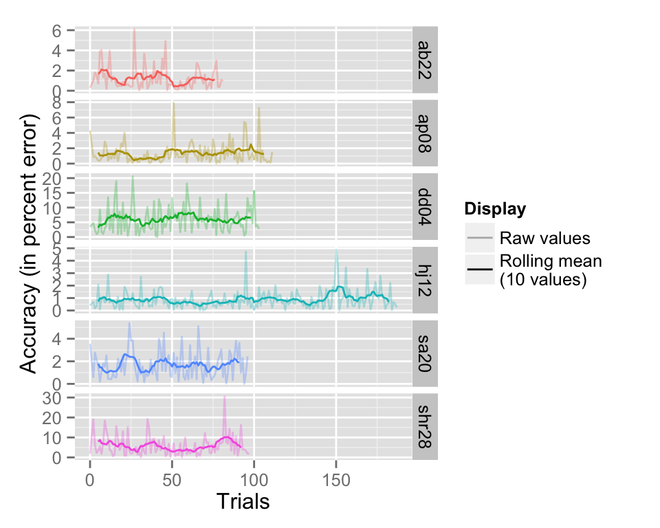

## Durations of trials

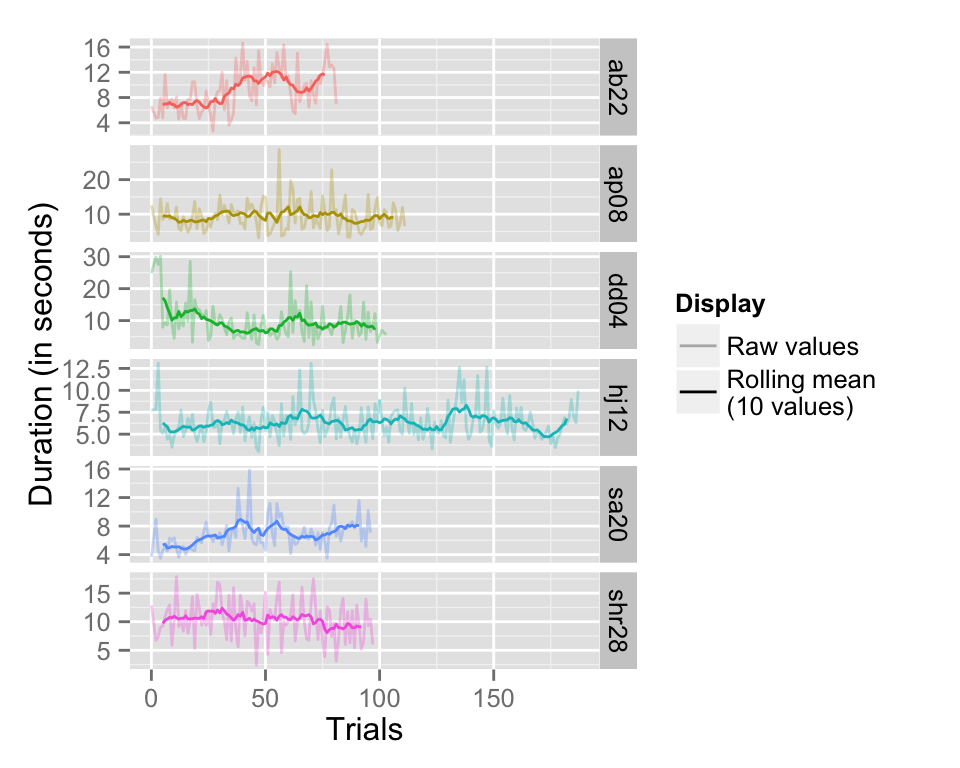

## Accuracy in function of duration for each trial

Finally, to see if the variability of the results is associated with duration, here is the plot of scores against duration. Each point is a trial.

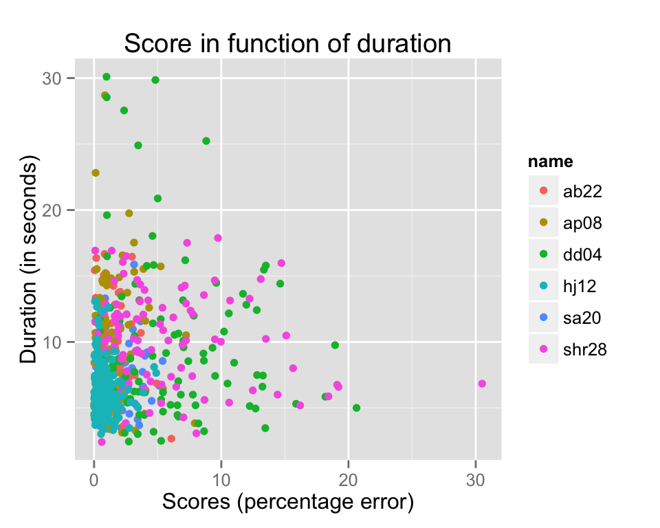

## Accuracy in function of frequency of the target tone

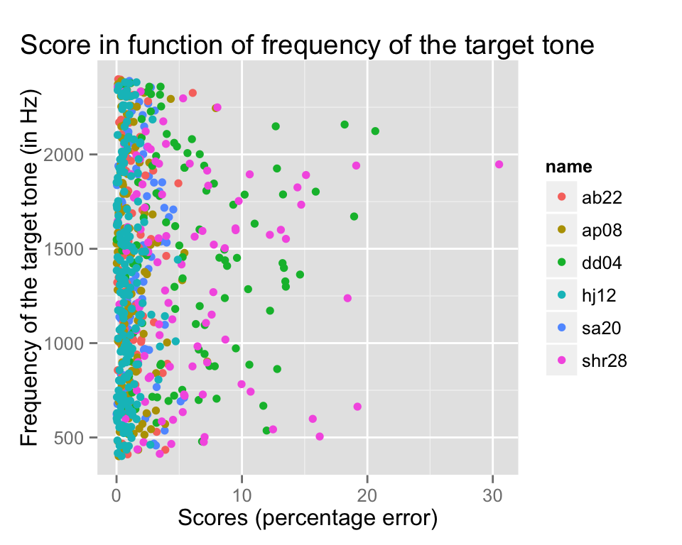

## Comparison of frequency thresholds and accuracy

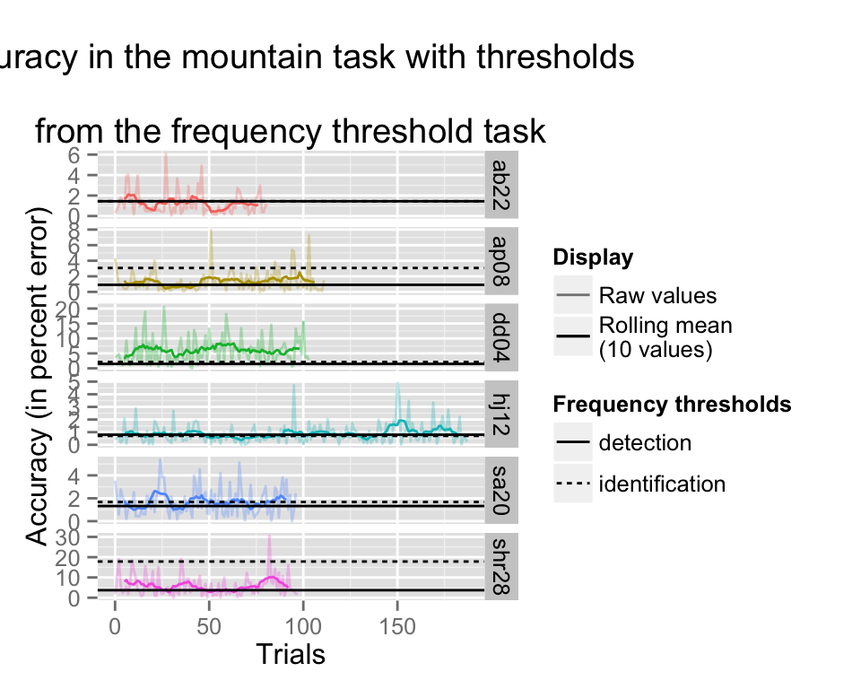

## Global analyses

## Frequency threshold task

### Mean of deltaF in function of trials in the detection and identification task

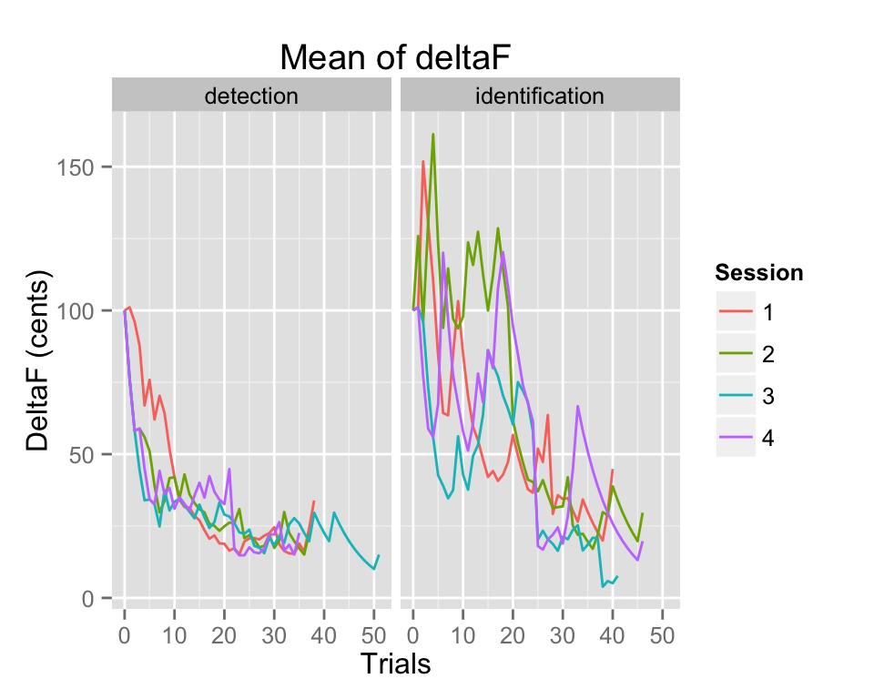

## Mean of thresholds among sessions

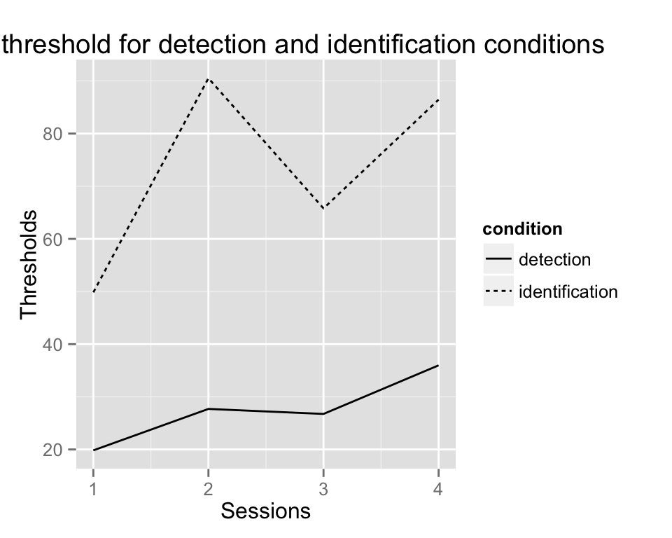

```
##  setting  value
##  version  R version 3.1.3 (2015-03-09)
##  system   x86_64, darwin13.4.0
##  ui       X11
##  language (EN)
##  collate  en_US.UTF-8
##  tz       Europe/Paris
```

```
## Packages ------------------------------------------------------------------
```

[output not shown]